# PCIT-CoS-Waitlist RCT Paper 1: DPICS LP

Nancy Briggs

2024-03-19

I was not happy with modelling this DPICS variable as a proportion of total verbalisation since all the proportions ended up being so small (total verbalisations were in the hundreds, with LP actions being small, usually <10%).

So I switched to a poisson model, with no offset, simply looking at total number of LP verbalisations, and I am much happier with the output and results.

In the results, the “effect size” the the ratio of the means.

### DPICS LP

#### Descriptives

*Descriptives of Percent of Total Verbalisations*

| group | time | n | mean | sd | median | min | max |
| --- | --- | --- | --- | --- | --- | --- | --- |
| 1 | 1 | 30 | 0.2210880 | 0.3206588 | 0.0000000 | 0.0000000 | 1.2145749 |
| 1 | 2 | 22 | 5.5382177 | 2.5986858 | 5.9042553 | 1.0060362 | 11.4503817 |
| 1 | 3 | 18 | 3.3895218 | 3.2501617 | 2.5254669 | 0.3012048 | 14.1479100 |
| 2 | 1 | 29 | 0.3814791 | 0.6888285 | 0.0000000 | 0.0000000 | 2.7848101 |
| 2 | 2 | 12 | 0.6698353 | 0.8628171 | 0.4459375 | 0.0000000 | 2.9702970 |
| 2 | 3 | 5 | 0.3891770 | 0.2192215 | 0.3690037 | 0.1715266 | 0.7352941 |
| 3 | 1 | 30 | 0.4496523 | 0.7171679 | 0.0000000 | 0.0000000 | 2.9629630 |
| 3 | 2 | 26 | 0.5435205 | 0.7550378 | 0.2163444 | 0.0000000 | 2.9197080 |
| 3 | 3 | 0 | NaN | NA | NA | Inf | -Inf |

*Descriptives of Total Number of LP*

| group | time | n | mean | sd | median | min | max |
| --- | --- | --- | --- | --- | --- | --- | --- |
| 1 | 1 | 30 | 0.7333333 | 1.0148325 | 0.0 | 0 | 3 |
| 1 | 2 | 22 | 19.8636364 | 8.2939763 | 19.5 | 5 | 40 |
| 1 | 3 | 18 | 11.4444444 | 10.5341027 | 9.0 | 1 | 44 |
| 2 | 1 | 29 | 1.5172414 | 2.6941827 | 0.0 | 0 | 11 |
| 2 | 2 | 12 | 2.8333333 | 3.5887028 | 2.0 | 0 | 12 |
| 2 | 3 | 5 | 1.4000000 | 0.5477226 | 1.0 | 1 | 2 |
| 3 | 1 | 30 | 1.5000000 | 2.1294325 | 0.0 | 0 | 8 |
| 3 | 2 | 26 | 2.0000000 | 2.7856777 | 1.0 | 0 | 12 |
| 3 | 3 | 0 | NaN | NA | NA | Inf | -Inf |

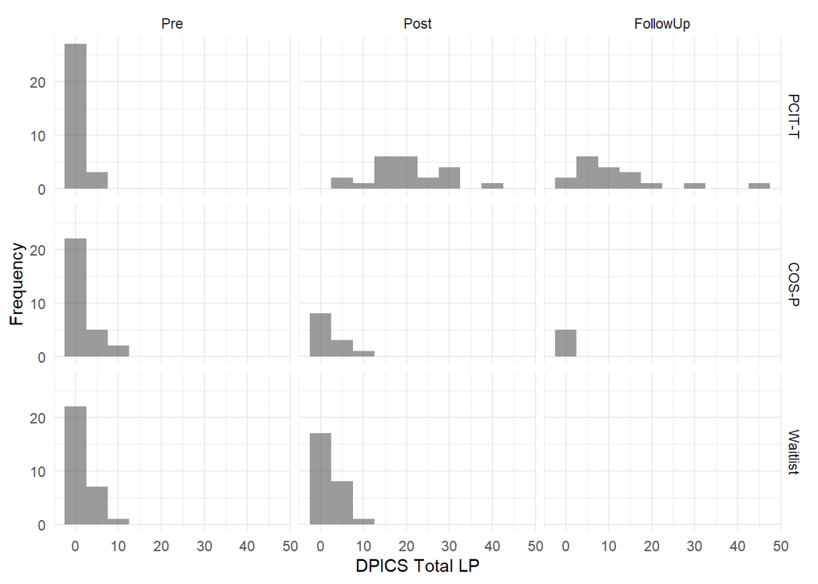

#### Model & Results

A generalized linear mixed model (GLMM) with random effect for individual and fixed effects of group, time and the interaction was run on the number of LP responses. A poisson distribution was specified with a log link. Estimated marginal means were obtained, and contrasts specified to test Hypothesis 1 and Hypothesis 2. Assumptions on the residuals were examined using simulated residuals (see below).

```
## fixed-effect model matrix is rank deficient so dropping 1 column / coefficient
```

This is the ANOVA table for the model. p-values are likelihood ratio tests for adding the new term to the model just before. A p-value <0.05 indicates that adding that term results in better model fit.

|  | Effect | npar | AIC | BIC | logLik | deviance | Chisq | Df | Pr(>Chisq) |
| --- | --- | --- | --- | --- | --- | --- | --- | --- | --- |
| result0 | Intercept | 2 | 1276.8787 | 1283.1737 | -636.4394 | 1272.8787 | NA | NA | NA |
| result1 | Group | 4 | 1252.3182 | 1264.9082 | -622.1591 | 1244.3182 | 28.56051 | 2 | 6e-07 |
| result2 | Time | 6 | 875.5211 | 894.4061 | -431.7605 | 863.5211 | 380.79710 | 2 | 0e+00 |
| result3 | Group*Time | 9 | 752.5557 | 780.8831 | -367.2778 | 734.5557 | 128.96539 | 3 | 0e+00 |

```r
summary(result3)
```

```
## Generalized linear mixed model fit by maximum likelihood (Laplace
##   Approximation) [glmerMod]
##  Family: poisson  ( log )
## Formula: lp ~ group + time + group * time + (1 | id)
##    Data: p
##
##      AIC      BIC   logLik deviance df.resid
##    752.6    780.9   -367.3    734.6      163
##
## Scaled residuals:
##     Min      1Q  Median      3Q     Max
## -2.2075 -0.7292 -0.3804  0.4484  2.7793
##
## Random effects:
##  Groups Name        Variance Std.Dev.
##  id     (Intercept) 0.9061   0.9519
## Number of obs: 172, groups:  id, 89
##
## Fixed effects:
##              Estimate Std. Error z value Pr(>|z|)
## (Intercept)   -0.5099     0.2789  -1.828   0.0675 .
## group2         0.3600     0.3826   0.941   0.3468
## group3         0.3690     0.3768   0.979   0.3275
## time2          3.2366     0.2300  14.073  < 2e-16 ***
## time3          2.7159     0.2366  11.480  < 2e-16 ***
## group2:time2  -2.7539     0.3474  -7.928 2.23e-15 ***
## group3:time2  -2.9514     0.3107  -9.500  < 2e-16 ***
## group2:time3  -2.3158     0.5395  -4.292 1.77e-05 ***
## ---
## Signif. codes:  0 '***' 0.001 '**' 0.01 '*' 0.05 '.' 0.1 ' ' 1
##
## Correlation of Fixed Effects:
##             (Intr) group2 group3 time2  time3  grp2:2 grp3:2
## group2      -0.711
## group3      -0.722  0.566
## time2       -0.708  0.520  0.528
## time3       -0.690  0.505  0.513  0.929
## group2:tim2  0.471 -0.508 -0.344 -0.662 -0.615
## group3:tim2  0.524 -0.385 -0.582 -0.740 -0.688  0.490
## group2:tim3  0.298 -0.374 -0.234 -0.408 -0.439  0.425  0.302
## fit warnings:
## fixed-effect model matrix is rank deficient so dropping 1 column / coefficient
```

#### Estimated Means & Change

Estimated means for each Treatment and Time are presented. In addition, within-group change between time points is presented with 95% CIs.

Adjusted p-value from Bonferroni correction.

##### Group mean at each timepoint

Estimated Mean Number of LP

| Time | Group | Mean | SE | LowerCL | UpperCL |
| --- | --- | --- | --- | --- | --- |
| 1 | 1 | 0.601 | 0.168 | 0.348 | 1.037 |
| 2 | 1 | 15.282 | 3.051 | 10.334 | 22.599 |
| 3 | 1 | 9.079 | 1.876 | 6.055 | 13.613 |
| 1 | 2 | 0.861 | 0.232 | 0.508 | 1.459 |
| 2 | 2 | 1.395 | 0.435 | 0.757 | 2.570 |
| 3 | 2 | 1.284 | 0.634 | 0.488 | 3.378 |
| 1 | 3 | 0.869 | 0.226 | 0.521 | 1.448 |
| 2 | 3 | 1.155 | 0.299 | 0.696 | 1.917 |
| 3 | 3 | NA | NA | NA | NA |

##### Group mean difference at each timepoint

Between-Group Differences

| Comparison | Time | Ratio | SE | z | p | adj p | Lower CL | Upper CL |
| --- | --- | --- | --- | --- | --- | --- | --- | --- |
| 1 / 2 | 1 | 0.698 | 0.267 | -0.941 | 0.614 | 1.000 | 0.285 | 1.711 |
| 1 / 3 | 1 | 0.691 | 0.261 | -0.979 | 0.590 | 0.983 | 0.286 | 1.672 |
| 2 / 3 | 1 | 0.991 | 0.351 | -0.025 | 1.000 | 1.000 | 0.432 | 2.271 |
| 1 / 2 | 2 | 10.957 | 3.980 | 6.590 | 0.000 | 0.000 | 4.676 | 25.671 |
| 1 / 3 | 2 | 13.229 | 4.230 | 8.075 | 0.000 | 0.000 | 6.252 | 27.991 |
| 2 / 3 | 2 | 1.207 | 0.463 | 0.491 | 0.875 | 1.000 | 0.492 | 2.966 |
| 1 / 2 | 3 | 7.070 | 3.762 | 3.675 | 0.001 | 0.001 | 2.031 | 24.608 |
| 1 / 3 | 3 | NA | NA | NA | NA | NA | NA | NA |
| 2 / 3 | 3 | NA | NA | NA | NA | NA | NA | NA |

* Effect size here is the ratio of differences. A value greater than 1 indicates a proportion change from the reference group.

Here you can see that Group1 has a lower number of LP at time 1 than Group1 (Ratio=.69), but at Time 2, it is much higher (ratio=10.96).

##### Change within each group

Within-Group Change

| Change | Group | Ratio | SE | z | p | adj p | Lower CL | Upper CL |
| --- | --- | --- | --- | --- | --- | --- | --- | --- |
| 2 / 1 | 1 | 25.447 | 5.852 | 14.073 | 0.000 | 0.000 | 14.844 | 43.624 |
| 3 / 1 | 1 | 15.118 | 3.577 | 11.480 | 0.000 | 0.000 | 8.683 | 26.320 |
| 3 / 2 | 1 | 0.594 | 0.052 | -5.914 | 0.000 | 0.000 | 0.483 | 0.730 |
| 2 / 1 | 2 | 1.620 | 0.422 | 1.853 | 0.153 | 0.192 | 0.880 | 2.984 |
| 3 / 1 | 2 | 1.492 | 0.723 | 0.825 | 0.687 | 1.000 | 0.479 | 4.646 |
| 3 / 2 | 2 | 0.921 | 0.456 | -0.167 | 0.985 | 1.000 | 0.289 | 2.936 |
| 2 / 1 | 3 | 1.330 | 0.278 | 1.366 | 0.359 | 0.516 | 0.815 | 2.170 |
| 3 / 1 | 3 | NA | NA | NA | NA | NA | NA | NA |
| 3 / 2 | 3 | NA | NA | NA | NA | NA | NA | NA |

* Effect size here is the ratio of change. A value greater than 1 indicates a proportion change from the reference timepoint.

Here, you can see that the effect size for change in group1 from T1 to T2 is 25.4. This can be interpreted as: the number of LP at time 2 was 25.4 times that of LP at time1. That’s huge! The value for group2 is 1.6, showing an increase in 1.6 times LP at time 1, but it is so much smaller than the relative increase for Group1.

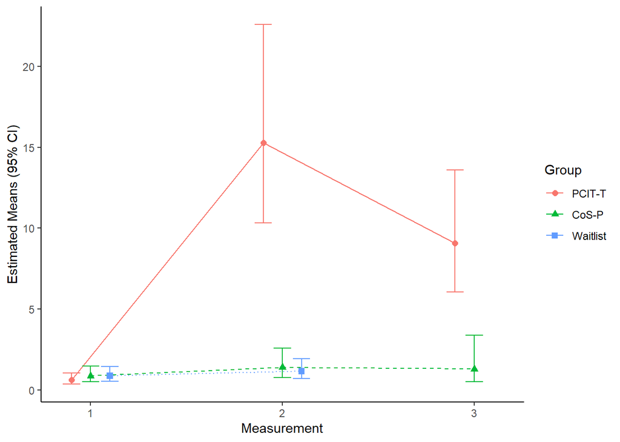

#### Hypothesis 1

We hypothesize that from baseline (‘T1’) to post-treatment/waitlist (‘T2’) there will be a gradient effect, whereby parent-child dyads who receive PCIT-T will show the greatest gains and parent-child dyads who receive no treatment will show the least gains. For the outcome, then, the null hypothesis is:

$H_0: \text {mean change}(\text{PCIT-T}) = \text {mean change}(\text{CoS-P}) = \text {mean change}(\text{Waitlist})$ $H_A: \text {mean change}(\text{PCIT-T}) > \text {mean change}(\text{CoS-P}) > \text {mean change}(\text{Waitlist})$

This is a joint hypothesis test.

First, confirming that the ordering of the means is as hypothesized:

```
## group = 1:
##  contrast  ratio     SE  df asymp.LCL asymp.UCL
##  2 / 1    25.447 5.8524 Inf    14.844     43.62
##  3 / 1    15.118 3.5765 Inf     8.683     26.32
##  3 / 2     0.594 0.0523 Inf     0.483      0.73
##
## group = 2:
##  contrast  ratio     SE  df asymp.LCL asymp.UCL
##  2 / 1     1.620 0.4221 Inf     0.880      2.98
##  3 / 1     1.492 0.7232 Inf     0.479      4.65
##  3 / 2     0.921 0.4556 Inf     0.289      2.94
##
## group = 3:
##  contrast  ratio     SE  df asymp.LCL asymp.UCL
##  2 / 1     1.330 0.2777 Inf     0.815      2.17
##  3 / 1    nonEst     NA  NA        NA        NA
##  3 / 2    nonEst     NA  NA        NA        NA
##
## Confidence level used: 0.95
## Conf-level adjustment: tukey method for comparing a family of 3 estimates
## Intervals are back-transformed from the log scale
```

so, change from t1 to t2 is represented as an rate ratio. They way these results are presented, a value greater than 1 means that there is an *increase* from T1 to T2.

Now, to get the p-value associated with the joint hypothesis.

```r
## Specify contrast matrices
# Hyp1 is 1 df test
# could use alternative="less" ir alternative="greater" in glht
hyp1   <- matrix(c(0, 0,0, 0,0, -1,0,0 ),1)
# Hyp2 is 1 df test,
hyp2   <- matrix(c(0, 0,0, 0,1, 0,1,0 ),1)


# hypF is combined 2df test. Yes!
h<-rbind(hyp1,hyp2)
hypF <- as.matrix(h)
GlobalF <- glht(result3, linfct = hypF, test = Ftest())
GlobalF$linfct
```

```
##   (Intercept) group2 group3 time2 time3 group2:time2 group3:time2 group2:time3
## 1           0      0      0     0     0           -1            0            0
## 2           0      0      0     0     1            0            1            0
```

```r
summary(GlobalF, test = Ftest())
```

```
##
##   General Linear Hypotheses
##
## Linear Hypotheses:
##        Estimate
## 1 == 0   2.7539
## 2 == 0  -0.2355
##
## Global Test:
##       F DF1 DF2    Pr(>F)
## 1 31.75   2 163 2.263e-12
```

```r
#also see this webpage for more on contrasts https://rcompanion.org/rcompanion/h_01.html
```

p<0.05 so this hypothesis is supported.

#### Hypothesis 2

There will be a gradient of size of change from T2 to T3 such that the change in the PCIT-T group > the change in the CoS-P group. This isn’t really a gradient; it’s just 1 hypothesis.

First, the change in PCITT and COSP from time 2 to time 3:

```
## group = 1:
##  time   rate    SE  df asymp.LCL asymp.UCL
##  1     0.601 0.168 Inf     0.348      1.04
##  2    15.282 3.051 Inf    10.334     22.60
##  3     9.079 1.876 Inf     6.055     13.61
##
## group = 2:
##  time   rate    SE  df asymp.LCL asymp.UCL
##  1     0.861 0.232 Inf     0.508      1.46
##  2     1.395 0.435 Inf     0.757      2.57
##  3     1.284 0.634 Inf     0.488      3.38
##
## group = 3:
##  time   rate    SE  df asymp.LCL asymp.UCL
##  1     0.869 0.226 Inf     0.521      1.45
##  2     1.155 0.299 Inf     0.696      1.92
##  3    nonEst    NA  NA        NA        NA
##
## Confidence level used: 0.95
## Intervals are back-transformed from the log scale
```

```
## group = 1:
##  contrast  ratio     SE  df asymp.LCL asymp.UCL
##  2 / 1    25.447 5.8524 Inf    14.844     43.62
##  3 / 1    15.118 3.5765 Inf     8.683     26.32
##  3 / 2     0.594 0.0523 Inf     0.483      0.73
##
## group = 2:
##  contrast  ratio     SE  df asymp.LCL asymp.UCL
##  2 / 1     1.620 0.4221 Inf     0.880      2.98
##  3 / 1     1.492 0.7232 Inf     0.479      4.65
##  3 / 2     0.921 0.4556 Inf     0.289      2.94
##
## group = 3:
##  contrast  ratio     SE  df asymp.LCL asymp.UCL
##  2 / 1     1.330 0.2777 Inf     0.815      2.17
##  3 / 1    nonEst     NA  NA        NA        NA
##  3 / 2    nonEst     NA  NA        NA        NA
##
## Confidence level used: 0.95
## Conf-level adjustment: tukey method for comparing a family of 3 estimates
## Intervals are back-transformed from the log scale
```

```r
## Specify contrast matrices
# Hyp1 is 1 df test
# could use alternative="less" ir alternative="greater" in glht
hyp2   <- matrix(c(0, 0,0, 0,0, -1,0,1 ),1)
hyp2F <- glht(result3, linfct = hyp2)
summary(hyp2F)
```

```
##
##   Simultaneous Tests for General Linear Hypotheses
##
## Fit: glmer(formula = lp ~ group + time + group * time + (1 | id),
##     data = p, family = poisson)
##
## Linear Hypotheses:
##        Estimate Std. Error z value Pr(>|z|)
## 1 == 0   0.4381     0.5025   0.872    0.383
## (Adjusted p values reported -- single-step method)
```

```r
#also see this webpage for more on contrasts https://rcompanion.org/rcompanion/h_01.html
```

p>0.05, so this null hypothesis cannot be rejected.

#### Residuals

Before interpretation, we should examine model assumptions.

For this model (A generalized linear mixed model with poisson distribution and log link, with random effect for individual), we have to use a different residual than for a linear mixed model. These are simulated residuals, using the DHARMa package in R (citation below).

Under H0 (perfect model, no violations of assumptions), we would expect a straight line in the QQplot. Also, scatterplot should show similar spread across the x-axis.

There are no violations of assumptions.

```r
library(DHARMa)
```

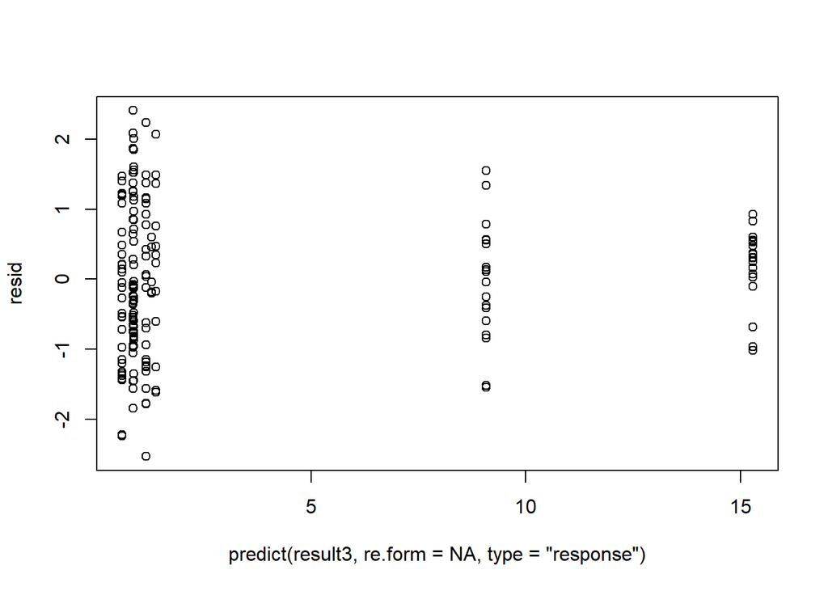

```r
sim= simulateResiduals(result3)
resid = residuals(sim, quantileFunction = qnorm, outlierValues = c(-7,7))
plot(resid~predict(result3, re.form = NA,type="response"))
```

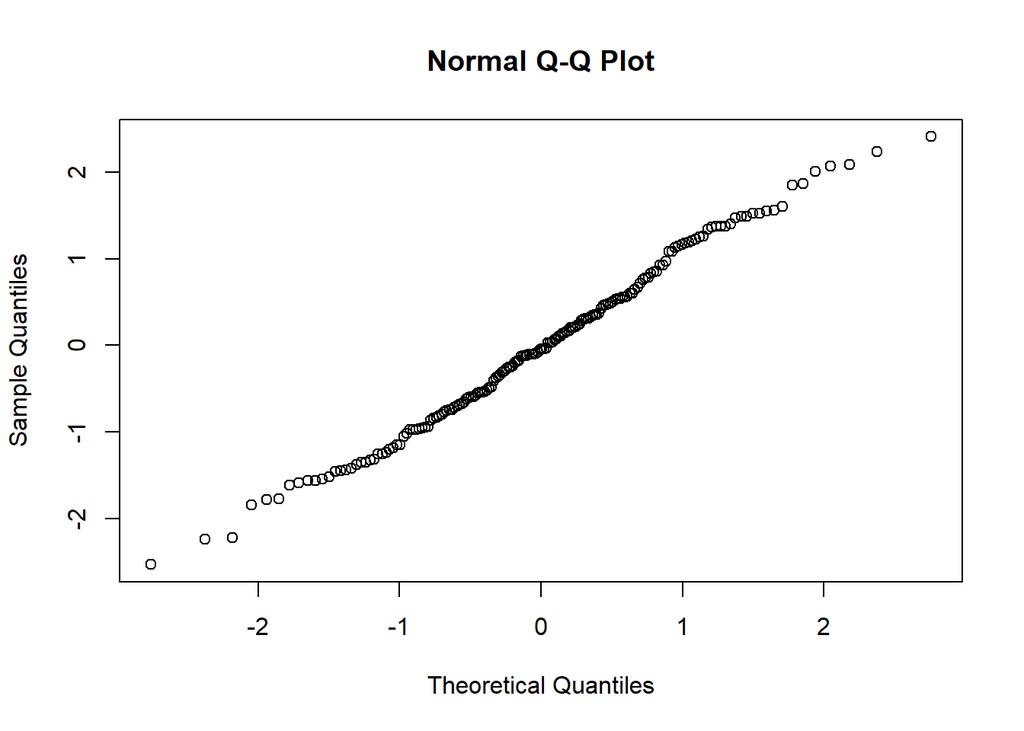

```r
qqnorm(resid)
```

```r
citation("DHARMa")
```

```
##
##
##   Florian Hartig (2022). DHARMa: Residual Diagnostics for Hierarchical
##   (Multi-Level / Mixed) Regression Models. R package version 0.4.5.
##   https://CRAN.R-project.org/package=DHARMa
##
## A BibTeX entry for LaTeX users is
##
##   @Manual{,
##     title = {DHARMa: Residual Diagnostics for Hierarchical (Multi-Level / Mixed)
## Regression Models},
##     author = {Florian Hartig},
##     year = {2022},
##     note = {R package version 0.4.5},
##     url = {https://CRAN.R-project.org/package=DHARMa},
##   }
```

```r
rm(list = ls())
```